# Risk Factor Analysis

## Outcome Variable

**Outcome Variable:** whz

## Predictor Variables

**Intervention Variable:** mage

**Adjustment Set:**

unadjusted

## Stratifying Variables

The analysis was stratified on these variable(s):

- agecat
- studyid
- country

## Data Summary

| agecat | studyid | country | mage | n_cell | n |
| --- | --- | --- | --- | --- | --- |
| Birth | CMC-V-BCS-2002 | INDIA | [20-30) | 75 | 86 |
| Birth | CMC-V-BCS-2002 | INDIA | <20 | 7 | 86 |
| Birth | CMC-V-BCS-2002 | INDIA | >=30 | 4 | 86 |
| Birth | COHORTS | GUATEMALA | [20-30) | 367 | 756 |
| Birth | COHORTS | GUATEMALA | <20 | 101 | 756 |
| Birth | COHORTS | GUATEMALA | >=30 | 288 | 756 |
| Birth | COHORTS | INDIA | [20-30) | 2965 | 4405 |
| Birth | COHORTS | INDIA | <20 | 337 | 4405 |
| Birth | COHORTS | INDIA | >=30 | 1103 | 4405 |
| Birth | COHORTS | PHILIPPINES | [20-30) | 1744 | 2899 |
| Birth | COHORTS | PHILIPPINES | <20 | 354 | 2899 |
| Birth | COHORTS | PHILIPPINES | >=30 | 801 | 2899 |
| Birth | EE | PAKISTAN | [20-30) | 68 | 177 |
| Birth | EE | PAKISTAN | <20 | 1 | 177 |
| Birth | EE | PAKISTAN | >=30 | 108 | 177 |
| Birth | GMS-Nepal | NEPAL | [20-30) | 421 | 641 |
| Birth | GMS-Nepal | NEPAL | <20 | 125 | 641 |
| Birth | GMS-Nepal | NEPAL | >=30 | 95 | 641 |
| Birth | IRC | INDIA | [20-30) | 289 | 343 |
| Birth | IRC | INDIA | <20 | 28 | 343 |
| Birth | IRC | INDIA | >=30 | 26 | 343 |
| Birth | Keneba | GAMBIA | [20-30) | 670 | 1466 |
| Birth | Keneba | GAMBIA | <20 | 224 | 1466 |
| Birth | Keneba | GAMBIA | >=30 | 572 | 1466 |
| Birth | MAL-ED | BANGLADESH | [20-30) | 148 | 215 |
| Birth | MAL-ED | BANGLADESH | <20 | 28 | 215 |
| Birth | MAL-ED | BANGLADESH | >=30 | 39 | 215 |
| Birth | MAL-ED | BRAZIL | [20-30) | 39 | 62 |
| Birth | MAL-ED | BRAZIL | <20 | 8 | 62 |
| Birth | MAL-ED | BRAZIL | >=30 | 15 | 62 |

[output cut: 174 more lines]

The following strata were considered:

- agecat: 24 months, studyid: CMC-V-BCS-2002, country: INDIA
- agecat: 24 months, studyid: COHORTS, country: GUATEMALA
- agecat: 24 months, studyid: COHORTS, country: INDIA
- agecat: 24 months, studyid: COHORTS, country: PHILIPPINES
- agecat: 24 months, studyid: EE, country: PAKISTAN
- agecat: 24 months, studyid: GMS-Nepal, country: NEPAL
- agecat: 24 months, studyid: IRC, country: INDIA
- agecat: 24 months, studyid: Keneba, country: GAMBIA
- agecat: 24 months, studyid: LCNI-5, country: MALAWI
- agecat: 24 months, studyid: MAL-ED, country: BANGLADESH
- agecat: 24 months, studyid: MAL-ED, country: BRAZIL
- agecat: 24 months, studyid: MAL-ED, country: INDIA
- agecat: 24 months, studyid: MAL-ED, country: NEPAL
- agecat: 24 months, studyid: MAL-ED, country: PERU
- agecat: 24 months, studyid: MAL-ED, country: SOUTH AFRICA
- agecat: 24 months, studyid: MAL-ED, country: TANZANIA, UNITED REPUBLIC OF
- agecat: 24 months, studyid: NIH-Birth, country: BANGLADESH
- agecat: 24 months, studyid: NIH-Crypto, country: BANGLADESH
- agecat: 24 months, studyid: PROBIT, country: BELARUS
- agecat: 24 months, studyid: PROVIDE, country: BANGLADESH
- agecat: 24 months, studyid: TanzaniaChild2, country: TANZANIA, UNITED REPUBLIC OF
- agecat: 24 months, studyid: ZVITAMBO, country: ZIMBABWE
- agecat: 6 months, studyid: CMC-V-BCS-2002, country: INDIA
- agecat: 6 months, studyid: COHORTS, country: GUATEMALA
- agecat: 6 months, studyid: COHORTS, country: INDIA
- agecat: 6 months, studyid: COHORTS, country: PHILIPPINES
- agecat: 6 months, studyid: EE, country: PAKISTAN
- agecat: 6 months, studyid: GMS-Nepal, country: NEPAL
- agecat: 6 months, studyid: Guatemala BSC, country: GUATEMALA
- agecat: 6 months, studyid: IRC, country: INDIA
- agecat: 6 months, studyid: Keneba, country: GAMBIA
- agecat: 6 months, studyid: LCNI-5, country: MALAWI
- agecat: 6 months, studyid: MAL-ED, country: BANGLADESH
- agecat: 6 months, studyid: MAL-ED, country: BRAZIL
- agecat: 6 months, studyid: MAL-ED, country: INDIA
- agecat: 6 months, studyid: MAL-ED, country: NEPAL
- agecat: 6 months, studyid: MAL-ED, country: PERU
- agecat: 6 months, studyid: MAL-ED, country: SOUTH AFRICA
- agecat: 6 months, studyid: MAL-ED, country: TANZANIA, UNITED REPUBLIC OF
- agecat: 6 months, studyid: NIH-Birth, country: BANGLADESH
- agecat: 6 months, studyid: NIH-Crypto, country: BANGLADESH
- agecat: 6 months, studyid: PROBIT, country: BELARUS
- agecat: 6 months, studyid: PROVIDE, country: BANGLADESH
- agecat: 6 months, studyid: SAS-CompFeed, country: INDIA
- agecat: 6 months, studyid: SAS-FoodSuppl, country: INDIA
- agecat: 6 months, studyid: TanzaniaChild2, country: TANZANIA, UNITED REPUBLIC OF
- agecat: 6 months, studyid: ZVITAMBO, country: ZIMBABWE
- agecat: Birth, studyid: CMC-V-BCS-2002, country: INDIA
- agecat: Birth, studyid: COHORTS, country: GUATEMALA
- agecat: Birth, studyid: COHORTS, country: INDIA
- agecat: Birth, studyid: COHORTS, country: PHILIPPINES
- agecat: Birth, studyid: EE, country: PAKISTAN
- agecat: Birth, studyid: GMS-Nepal, country: NEPAL
- agecat: Birth, studyid: IRC, country: INDIA
- agecat: Birth, studyid: Keneba, country: GAMBIA
- agecat: Birth, studyid: MAL-ED, country: BANGLADESH
- agecat: Birth, studyid: MAL-ED, country: BRAZIL
- agecat: Birth, studyid: MAL-ED, country: INDIA
- agecat: Birth, studyid: MAL-ED, country: NEPAL
- agecat: Birth, studyid: MAL-ED, country: PERU
- agecat: Birth, studyid: MAL-ED, country: SOUTH AFRICA
- agecat: Birth, studyid: MAL-ED, country: TANZANIA, UNITED REPUBLIC OF
- agecat: Birth, studyid: NIH-Birth, country: BANGLADESH
- agecat: Birth, studyid: NIH-Crypto, country: BANGLADESH
- agecat: Birth, studyid: PROBIT, country: BELARUS
- agecat: Birth, studyid: PROVIDE, country: BANGLADESH
- agecat: Birth, studyid: SAS-CompFeed, country: INDIA
- agecat: Birth, studyid: ZVITAMBO, country: ZIMBABWE

### Dropped Strata

Some strata were dropped due to rare outcomes:

- agecat: Birth, studyid: CMC-V-BCS-2002, country: INDIA
- agecat: Birth, studyid: EE, country: PAKISTAN
- agecat: Birth, studyid: MAL-ED, country: INDIA
- agecat: Birth, studyid: MAL-ED, country: NEPAL
- agecat: 6 months, studyid: EE, country: PAKISTAN
- agecat: 24 months, studyid: EE, country: PAKISTAN
- agecat: 24 months, studyid: MAL-ED, country: NEPAL
- agecat: 24 months, studyid: TanzaniaChild2, country: TANZANIA, UNITED REPUBLIC OF

## Methods Detail

We’re interested in the causal parameters $E[Y_a]$ for all values of $a \in \mathcal{A}$. These parameters represent the mean outcome if, possibly contrary to fact, we intervened to set all units to have $A=a$. Under the randomization and positivity assumptions, these are identified by the statistical parameters $\psi_a=E_W[E_{Y|A,W}(Y|A=a,W)]$. In addition, we’re interested in the mean of $Y$, $E[Y]$ under no intervention (the observed mean). We will estimate these parameters by using SuperLearner to fit the relevant likelihood factors – $E_{Y|A,W}(Y|A=a,W)$ and $p(A=a|W)$, and then updating our likelihood fit using a joint TMLE.

For unadjusted analyses ($W=\{\}$), initial likelihoods were estimated using Lrnr_glm to estimate the simple $E(Y|A)$ and Lrnr_mean to estimate $p(A)$. For adjusted analyses, a small library containing Lrnr_glmnet, Lrnr_xgboost, and Lrnr_mean was used.

# Results Detail

## Results Plots

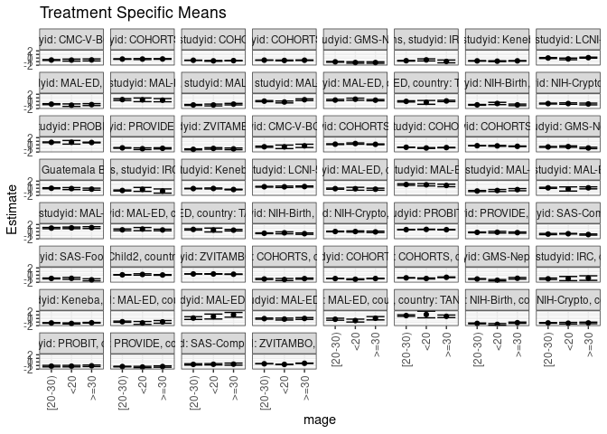

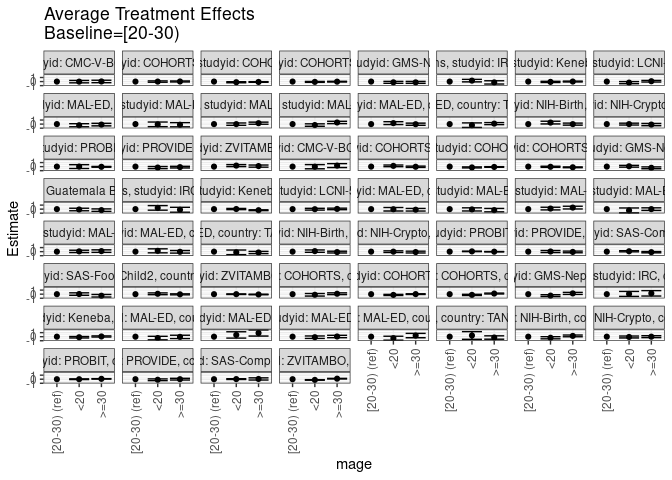

[figure not shown]

## Results Table

### Parameter: TSM

| agecat | studyid | country | intervention_level | baseline_level | estimate | ci_lower | ci_upper |
| --- | --- | --- | --- | --- | --- | --- | --- |
| Birth | COHORTS | GUATEMALA | [20-30) | NA | -1.0812807 | -1.2215533 | -0.9410080 |
| Birth | COHORTS | GUATEMALA | <20 | NA | -1.2331683 | -1.5179353 | -0.9484013 |
| Birth | COHORTS | GUATEMALA | >=30 | NA | -0.9777778 | -1.1454746 | -0.8100810 |
| Birth | COHORTS | INDIA | [20-30) | NA | -0.9629073 | -1.0047654 | -0.9210491 |
| Birth | COHORTS | INDIA | <20 | NA | -1.1540653 | -1.2795515 | -1.0285791 |
| Birth | COHORTS | INDIA | >=30 | NA | -0.9499275 | -1.0236697 | -0.8761853 |
| Birth | COHORTS | PHILIPPINES | [20-30) | NA | -0.7637443 | -0.8236671 | -0.7038214 |
| Birth | COHORTS | PHILIPPINES | <20 | NA | -0.9422316 | -1.0782257 | -0.8062375 |
| Birth | COHORTS | PHILIPPINES | >=30 | NA | -0.6087890 | -0.6944839 | -0.5230942 |
| Birth | GMS-Nepal | NEPAL | [20-30) | NA | -1.0744893 | -1.1814253 | -0.9675533 |
| Birth | GMS-Nepal | NEPAL | <20 | NA | -1.4335200 | -1.6272977 | -1.2397423 |
| Birth | GMS-Nepal | NEPAL | >=30 | NA | -0.8851579 | -1.1125334 | -0.6577824 |
| Birth | IRC | INDIA | [20-30) | NA | -1.0314533 | -1.2379730 | -0.8249335 |
| Birth | IRC | INDIA | <20 | NA | -0.9657143 | -1.5437779 | -0.3876507 |
| Birth | IRC | INDIA | >=30 | NA | -0.8269231 | -1.4629238 | -0.1909223 |
| Birth | Keneba | GAMBIA | [20-30) | NA | -1.2348284 | -1.3256256 | -1.1440311 |
| Birth | Keneba | GAMBIA | <20 | NA | -1.3709821 | -1.5202118 | -1.2217525 |
| Birth | Keneba | GAMBIA | >=30 | NA | -1.1818094 | -1.2852383 | -1.0783806 |
| Birth | MAL-ED | BANGLADESH | [20-30) | NA | -0.8888851 | -1.0573115 | -0.7204588 |
| Birth | MAL-ED | BANGLADESH | <20 | NA | -1.2260714 | -1.6281317 | -0.8240111 |
| Birth | MAL-ED | BANGLADESH | >=30 | NA | -0.9388462 | -1.3149054 | -0.5627870 |
| Birth | MAL-ED | BRAZIL | [20-30) | NA | 0.1282051 | -0.2476806 | 0.5040909 |
| Birth | MAL-ED | BRAZIL | <20 | NA | 0.5562500 | -0.1284217 | 1.2409217 |
| Birth | MAL-ED | BRAZIL | >=30 | NA | 1.0353333 | 0.3801713 | 1.6904954 |
| Birth | MAL-ED | PERU | [20-30) | NA | -0.0278761 | -0.1858416 | 0.1300894 |
| Birth | MAL-ED | PERU | <20 | NA | -0.1534921 | -0.4132380 | 0.1062539 |
| Birth | MAL-ED | PERU | >=30 | NA | 0.0184615 | -0.2284224 | 0.2653455 |
| Birth | MAL-ED | SOUTH AFRICA | [20-30) | NA | -0.2015385 | -0.4788294 | 0.0757525 |
| Birth | MAL-ED | SOUTH AFRICA | <20 | NA | -0.5727273 | -0.9731275 | -0.1723271 |
| Birth | MAL-ED | SOUTH AFRICA | >=30 | NA | 0.0784848 | -0.3788211 | 0.5357908 |

[output cut: 150 more lines]

### Parameter: E(Y)

| agecat | studyid | country | intervention_level | baseline_level | estimate | ci_lower | ci_upper |
| --- | --- | --- | --- | --- | --- | --- | --- |
| Birth | COHORTS | GUATEMALA | NA | NA | -1.0621429 | -1.1631387 | -0.9611471 |
| Birth | COHORTS | INDIA | NA | NA | -0.9742815 | -1.0093427 | -0.9392203 |
| Birth | COHORTS | PHILIPPINES | NA | NA | -0.7427251 | -0.7890855 | -0.6963647 |
| Birth | GMS-Nepal | NEPAL | NA | NA | -1.1164431 | -1.2040134 | -1.0288728 |
| Birth | IRC | INDIA | NA | NA | -1.0105831 | -1.1973019 | -0.8238643 |
| Birth | Keneba | GAMBIA | NA | NA | -1.2349454 | -1.2972413 | -1.1726496 |
| Birth | MAL-ED | BANGLADESH | NA | NA | -0.9418605 | -1.0869834 | -0.7967375 |
| Birth | MAL-ED | BRAZIL | NA | NA | 0.4029032 | 0.0896793 | 0.7161272 |
| Birth | MAL-ED | PERU | NA | NA | -0.0520175 | -0.1725298 | 0.0684947 |
| Birth | MAL-ED | SOUTH AFRICA | NA | NA | -0.1925833 | -0.4053570 | 0.0201904 |
| Birth | MAL-ED | TANZANIA, UNITED REPUBLIC OF | NA | NA | 0.7624348 | 0.5710709 | 0.9537986 |
| Birth | NIH-Birth | BANGLADESH | NA | NA | -1.3545637 | -1.4492090 | -1.2599184 |
| Birth | NIH-Crypto | BANGLADESH | NA | NA | -1.2441513 | -1.3281130 | -1.1601897 |
| Birth | PROBIT | BELARUS | NA | NA | -1.1491782 | -1.3593933 | -0.9389630 |
| Birth | PROVIDE | BANGLADESH | NA | NA | -1.2984586 | -1.3752758 | -1.2216415 |
| Birth | SAS-CompFeed | INDIA | NA | NA | -0.6700453 | -0.8474950 | -0.4925957 |
| Birth | ZVITAMBO | ZIMBABWE | NA | NA | -0.5144298 | -0.5403185 | -0.4885410 |
| 6 months | CMC-V-BCS-2002 | INDIA | NA | NA | -0.5026766 | -0.6536848 | -0.3516685 |
| 6 months | COHORTS | GUATEMALA | NA | NA | 0.1940810 | 0.1226351 | 0.2655269 |
| 6 months | COHORTS | INDIA | NA | NA | -0.7119298 | -0.7444861 | -0.6793734 |
| 6 months | COHORTS | PHILIPPINES | NA | NA | -0.2938433 | -0.3352064 | -0.2524802 |
| 6 months | GMS-Nepal | NEPAL | NA | NA | -0.6038416 | -0.6899448 | -0.5177384 |
| 6 months | Guatemala BSC | GUATEMALA | NA | NA | -0.0619988 | -0.1773839 | 0.0533863 |
| 6 months | IRC | INDIA | NA | NA | -0.5989297 | -0.7344491 | -0.4634104 |
| 6 months | Keneba | GAMBIA | NA | NA | -0.1833609 | -0.2343611 | -0.1323607 |
| 6 months | LCNI-5 | MALAWI | NA | NA | 0.4409268 | 0.3613957 | 0.5204578 |
| 6 months | MAL-ED | BANGLADESH | NA | NA | -0.1376763 | -0.2664642 | -0.0088885 |
| 6 months | MAL-ED | BRAZIL | NA | NA | 0.9720774 | 0.8078144 | 1.1363403 |
| 6 months | MAL-ED | INDIA | NA | NA | -0.7077885 | -0.8346769 | -0.5809000 |
| 6 months | MAL-ED | NEPAL | NA | NA | 0.1104308 | -0.0208643 | 0.2417259 |
| 6 months | MAL-ED | PERU | NA | NA | 1.0528816 | 0.9313005 | 1.1744626 |
| 6 months | MAL-ED | SOUTH AFRICA | NA | NA | 0.5421785 | 0.3900443 | 0.6943126 |
| 6 months | MAL-ED | TANZANIA, UNITED REPUBLIC OF | NA | NA | 0.5362213 | 0.4049390 | 0.6675036 |
| 6 months | NIH-Birth | BANGLADESH | NA | NA | -0.4495343 | -0.5402027 | -0.3588659 |
| 6 months | NIH-Crypto | BANGLADESH | NA | NA | 0.0297622 | -0.0491685 | 0.1086930 |
| 6 months | PROBIT | BELARUS | NA | NA | 0.5741099 | 0.5141290 | 0.6340908 |
| 6 months | PROVIDE | BANGLADESH | NA | NA | -0.1990907 | -0.2817968 | -0.1163845 |
| 6 months | SAS-CompFeed | INDIA | NA | NA | -0.6657084 | -0.8024377 | -0.5289791 |
| 6 months | SAS-FoodSuppl | INDIA | NA | NA | -1.0121579 | -1.1280429 | -0.8962729 |
| 6 months | TanzaniaChild2 | TANZANIA, UNITED REPUBLIC OF | NA | NA | 0.0782666 | 0.0252568 | 0.1312764 |
| 6 months | ZVITAMBO | ZIMBABWE | NA | NA | 0.3103322 | 0.2846161 | 0.3360483 |
| 24 months | CMC-V-BCS-2002 | INDIA | NA | NA | -0.5571505 | -0.6585247 | -0.4557763 |
| 24 months | COHORTS | GUATEMALA | NA | NA | -0.2813755 | -0.3354674 | -0.2272835 |
| 24 months | COHORTS | INDIA | NA | NA | -0.6627749 | -0.6962103 | -0.6293395 |
| 24 months | COHORTS | PHILIPPINES | NA | NA | -0.6099592 | -0.6467541 | -0.5731643 |
| 24 months | GMS-Nepal | NEPAL | NA | NA | -1.1363107 | -1.2252817 | -1.0473398 |
| 24 months | IRC | INDIA | NA | NA | -0.7458150 | -0.8368180 | -0.6548120 |
| 24 months | Keneba | GAMBIA | NA | NA | -0.8079199 | -0.8550714 | -0.7607684 |
| 24 months | LCNI-5 | MALAWI | NA | NA | -0.0115944 | -0.1019822 | 0.0787935 |
| 24 months | MAL-ED | BANGLADESH | NA | NA | -0.8192925 | -0.9412667 | -0.6973182 |
| 24 months | MAL-ED | BRAZIL | NA | NA | 0.4626233 | 0.2567495 | 0.6684971 |
| 24 months | MAL-ED | INDIA | NA | NA | -0.9564667 | -1.0725632 | -0.8403701 |
| 24 months | MAL-ED | PERU | NA | NA | 0.1111982 | -0.0118399 | 0.2342362 |
| 24 months | MAL-ED | SOUTH AFRICA | NA | NA | 0.4090301 | 0.2879441 | 0.5301161 |
| 24 months | MAL-ED | TANZANIA, UNITED REPUBLIC OF | NA | NA | 0.0547975 | -0.0703378 | 0.1799328 |
| 24 months | NIH-Birth | BANGLADESH | NA | NA | -0.9097790 | -1.0080462 | -0.8115117 |
| 24 months | NIH-Crypto | BANGLADESH | NA | NA | -0.6103502 | -0.7050157 | -0.5156847 |
| 24 months | PROBIT | BELARUS | NA | NA | 0.6981406 | 0.5843775 | 0.8119038 |
| 24 months | PROVIDE | BANGLADESH | NA | NA | -0.8928670 | -0.9755153 | -0.8102187 |
| 24 months | ZVITAMBO | ZIMBABWE | NA | NA | -1.1845602 | -1.2836321 | -1.0854883 |

### Parameter: ATE

| agecat | studyid | country | intervention_level | baseline_level | estimate | ci_lower | ci_upper |
| --- | --- | --- | --- | --- | --- | --- | --- |
| Birth | COHORTS | GUATEMALA | [20-30) | [20-30) | 0.0000000 | 0.0000000 | 0.0000000 |
| Birth | COHORTS | GUATEMALA | <20 | [20-30) | -0.1518877 | -0.4693285 | 0.1655532 |
| Birth | COHORTS | GUATEMALA | >=30 | [20-30) | 0.1035029 | -0.1151261 | 0.3221319 |
| Birth | COHORTS | INDIA | [20-30) | [20-30) | 0.0000000 | 0.0000000 | 0.0000000 |
| Birth | COHORTS | INDIA | <20 | [20-30) | -0.1911580 | -0.3234414 | -0.0588746 |
| Birth | COHORTS | INDIA | >=30 | [20-30) | 0.0129798 | -0.0718142 | 0.0977738 |
| Birth | COHORTS | PHILIPPINES | [20-30) | [20-30) | 0.0000000 | 0.0000000 | 0.0000000 |
| Birth | COHORTS | PHILIPPINES | <20 | [20-30) | -0.1784874 | -0.3270981 | -0.0298767 |
| Birth | COHORTS | PHILIPPINES | >=30 | [20-30) | 0.1549553 | 0.0503878 | 0.2595227 |
| Birth | GMS-Nepal | NEPAL | [20-30) | [20-30) | 0.0000000 | 0.0000000 | 0.0000000 |
| Birth | GMS-Nepal | NEPAL | <20 | [20-30) | -0.3590307 | -0.5803565 | -0.1377049 |
| Birth | GMS-Nepal | NEPAL | >=30 | [20-30) | 0.1893314 | -0.0619353 | 0.4405981 |
| Birth | IRC | INDIA | [20-30) | [20-30) | 0.0000000 | 0.0000000 | 0.0000000 |
| Birth | IRC | INDIA | <20 | [20-30) | 0.0657390 | -0.5481078 | 0.6795858 |
| Birth | IRC | INDIA | >=30 | [20-30) | 0.2045302 | -0.4641606 | 0.8732210 |
| Birth | Keneba | GAMBIA | [20-30) | [20-30) | 0.0000000 | 0.0000000 | 0.0000000 |
| Birth | Keneba | GAMBIA | <20 | [20-30) | -0.1361538 | -0.3108353 | 0.0385277 |
| Birth | Keneba | GAMBIA | >=30 | [20-30) | 0.0530189 | -0.0846098 | 0.1906476 |
| Birth | MAL-ED | BANGLADESH | [20-30) | [20-30) | 0.0000000 | 0.0000000 | 0.0000000 |
| Birth | MAL-ED | BANGLADESH | <20 | [20-30) | -0.3371863 | -0.7730991 | 0.0987265 |
| Birth | MAL-ED | BANGLADESH | >=30 | [20-30) | -0.0499610 | -0.4620144 | 0.3620923 |
| Birth | MAL-ED | BRAZIL | [20-30) | [20-30) | 0.0000000 | 0.0000000 | 0.0000000 |
| Birth | MAL-ED | BRAZIL | <20 | [20-30) | 0.4280449 | -0.3530220 | 1.2091117 |
| Birth | MAL-ED | BRAZIL | >=30 | [20-30) | 0.9071282 | 0.1517955 | 1.6624609 |
| Birth | MAL-ED | PERU | [20-30) | [20-30) | 0.0000000 | 0.0000000 | 0.0000000 |
| Birth | MAL-ED | PERU | <20 | [20-30) | -0.1256160 | -0.4296243 | 0.1783924 |
| Birth | MAL-ED | PERU | >=30 | [20-30) | 0.0463376 | -0.2467576 | 0.3394329 |
| Birth | MAL-ED | SOUTH AFRICA | [20-30) | [20-30) | 0.0000000 | 0.0000000 | 0.0000000 |
| Birth | MAL-ED | SOUTH AFRICA | <20 | [20-30) | -0.3711888 | -0.8582315 | 0.1158539 |
| Birth | MAL-ED | SOUTH AFRICA | >=30 | [20-30) | 0.2800233 | -0.2547841 | 0.8148307 |

[output cut: 150 more lines]

### Parameter: PAR

| agecat | studyid | country | intervention_level | baseline_level | estimate | ci_lower | ci_upper |
| --- | --- | --- | --- | --- | --- | --- | --- |
| Birth | COHORTS | GUATEMALA | [20-30) | NA | 0.0191378 | -0.0846540 | 0.1229296 |
| Birth | COHORTS | INDIA | [20-30) | NA | -0.0113742 | -0.0363285 | 0.0135800 |
| Birth | COHORTS | PHILIPPINES | [20-30) | NA | 0.0210192 | -0.0166603 | 0.0586986 |
| Birth | GMS-Nepal | NEPAL | [20-30) | NA | -0.0419537 | -0.1058502 | 0.0219427 |
| Birth | IRC | INDIA | [20-30) | NA | 0.0208702 | -0.0542483 | 0.0959887 |
| Birth | Keneba | GAMBIA | [20-30) | NA | -0.0001171 | -0.0678618 | 0.0676276 |
| Birth | MAL-ED | BANGLADESH | [20-30) | NA | -0.0529753 | -0.1548253 | 0.0488746 |
| Birth | MAL-ED | BRAZIL | [20-30) | NA | 0.2746981 | 0.0264094 | 0.5229868 |
| Birth | MAL-ED | PERU | [20-30) | NA | -0.0241414 | -0.1455584 | 0.0972755 |
| Birth | MAL-ED | SOUTH AFRICA | [20-30) | NA | 0.0089551 | -0.1881873 | 0.2060975 |
| Birth | MAL-ED | TANZANIA, UNITED REPUBLIC OF | [20-30) | NA | -0.0562016 | -0.2275676 | 0.1151644 |
| Birth | NIH-Birth | BANGLADESH | [20-30) | NA | 0.0101376 | -0.0516228 | 0.0718980 |
| Birth | NIH-Crypto | BANGLADESH | [20-30) | NA | -0.0116887 | -0.0724498 | 0.0490725 |
| Birth | PROBIT | BELARUS | [20-30) | NA | 0.0155862 | -0.0004259 | 0.0315983 |
| Birth | PROVIDE | BANGLADESH | [20-30) | NA | -0.0159450 | -0.0678874 | 0.0359974 |
| Birth | SAS-CompFeed | INDIA | [20-30) | NA | 0.0108108 | -0.0267605 | 0.0483821 |
| Birth | ZVITAMBO | ZIMBABWE | [20-30) | NA | -0.0049390 | -0.0229138 | 0.0130358 |
| 6 months | CMC-V-BCS-2002 | INDIA | [20-30) | NA | 0.0276202 | -0.0496471 | 0.1048875 |
| 6 months | COHORTS | GUATEMALA | [20-30) | NA | 0.0074356 | -0.0656328 | 0.0805039 |
| 6 months | COHORTS | INDIA | [20-30) | NA | -0.0361150 | -0.0585490 | -0.0136809 |
| 6 months | COHORTS | PHILIPPINES | [20-30) | NA | -0.0532996 | -0.0880423 | -0.0185568 |
| 6 months | GMS-Nepal | NEPAL | [20-30) | NA | -0.0284732 | -0.0892205 | 0.0322740 |
| 6 months | Guatemala BSC | GUATEMALA | [20-30) | NA | -0.0679052 | -0.1608587 | 0.0250483 |
| 6 months | IRC | INDIA | [20-30) | NA | 0.0163578 | -0.0532078 | 0.0859233 |
| 6 months | Keneba | GAMBIA | [20-30) | NA | -0.0980744 | -0.1516585 | -0.0444903 |
| 6 months | LCNI-5 | MALAWI | [20-30) | NA | 0.0126850 | -0.0601451 | 0.0855151 |
| 6 months | MAL-ED | BANGLADESH | [20-30) | NA | -0.0294339 | -0.1191049 | 0.0602370 |
| 6 months | MAL-ED | BRAZIL | [20-30) | NA | -0.0678960 | -0.2003160 | 0.0645240 |
| 6 months | MAL-ED | INDIA | [20-30) | NA | 0.0539061 | -0.0091267 | 0.1169390 |
| 6 months | MAL-ED | NEPAL | [20-30) | NA | -0.0058125 | -0.0715975 | 0.0599726 |
| 6 months | MAL-ED | PERU | [20-30) | NA | 0.0471892 | -0.0748590 | 0.1692373 |
| 6 months | MAL-ED | SOUTH AFRICA | [20-30) | NA | 0.0196079 | -0.1447316 | 0.1839474 |
| 6 months | MAL-ED | TANZANIA, UNITED REPUBLIC OF | [20-30) | NA | -0.0969818 | -0.2240662 | 0.0301026 |
| 6 months | NIH-Birth | BANGLADESH | [20-30) | NA | -0.0092868 | -0.0729223 | 0.0543486 |
| 6 months | NIH-Crypto | BANGLADESH | [20-30) | NA | -0.0179650 | -0.0766633 | 0.0407332 |
| 6 months | PROBIT | BELARUS | [20-30) | NA | 0.0047008 | -0.0061362 | 0.0155378 |
| 6 months | PROVIDE | BANGLADESH | [20-30) | NA | -0.0093462 | -0.0608686 | 0.0421763 |
| 6 months | SAS-CompFeed | INDIA | [20-30) | NA | -0.0022256 | -0.0328925 | 0.0284412 |
| 6 months | SAS-FoodSuppl | INDIA | [20-30) | NA | -0.0828502 | -0.1646662 | -0.0010343 |
| 6 months | TanzaniaChild2 | TANZANIA, UNITED REPUBLIC OF | [20-30) | NA | -0.0041840 | -0.0430868 | 0.0347188 |
| 6 months | ZVITAMBO | ZIMBABWE | [20-30) | NA | -0.0139326 | -0.0322534 | 0.0043882 |
| 24 months | CMC-V-BCS-2002 | INDIA | [20-30) | NA | 0.0017628 | -0.0449995 | 0.0485250 |
| 24 months | COHORTS | GUATEMALA | [20-30) | NA | 0.0075531 | -0.0471447 | 0.0622509 |
| 24 months | COHORTS | INDIA | [20-30) | NA | -0.0362336 | -0.0595495 | -0.0129177 |
| 24 months | COHORTS | PHILIPPINES | [20-30) | NA | -0.0152432 | -0.0456228 | 0.0151363 |
| 24 months | GMS-Nepal | NEPAL | [20-30) | NA | -0.0664369 | -0.1316751 | -0.0011987 |
| 24 months | IRC | INDIA | [20-30) | NA | 0.0069158 | -0.0351308 | 0.0489624 |
| 24 months | Keneba | GAMBIA | [20-30) | NA | -0.0080409 | -0.0591910 | 0.0431093 |
| 24 months | LCNI-5 | MALAWI | [20-30) | NA | -0.0169471 | -0.1029667 | 0.0690726 |
| 24 months | MAL-ED | BANGLADESH | [20-30) | NA | -0.0601829 | -0.1429280 | 0.0225623 |
| 24 months | MAL-ED | BRAZIL | [20-30) | NA | -0.0484715 | -0.2172828 | 0.1203398 |
| 24 months | MAL-ED | INDIA | [20-30) | NA | 0.0188822 | -0.0351632 | 0.0729276 |
| 24 months | MAL-ED | PERU | [20-30) | NA | 0.0299822 | -0.0954940 | 0.1554584 |
| 24 months | MAL-ED | SOUTH AFRICA | [20-30) | NA | 0.0290930 | -0.1074433 | 0.1656293 |
| 24 months | MAL-ED | TANZANIA, UNITED REPUBLIC OF | [20-30) | NA | 0.0400925 | -0.0781403 | 0.1583253 |
| 24 months | NIH-Birth | BANGLADESH | [20-30) | NA | 0.0367112 | -0.0335624 | 0.1069848 |
| 24 months | NIH-Crypto | BANGLADESH | [20-30) | NA | -0.0184041 | -0.0866521 | 0.0498440 |
| 24 months | PROBIT | BELARUS | [20-30) | NA | -0.0089039 | -0.0556366 | 0.0378288 |
| 24 months | PROVIDE | BANGLADESH | [20-30) | NA | -0.0480259 | -0.0991892 | 0.0031373 |
| 24 months | ZVITAMBO | ZIMBABWE | [20-30) | NA | 0.0661645 | -0.0076951 | 0.1400240 |